# Data 622 Homework 2

Sung Lee

2022-03-24

# Assignment

Based on the latest topics presented, bring a dataset of your choice and create a Decision Tree where you can solve a classification or regression problem and predict the outcome of a particular feature or detail of the data used. Switch variables to generate 2 decision trees and compare the results. Create a random forest for regression and analyze the results. Based on real cases where decision trees went wrong, and ‘the bad & ugly’ aspects of decision trees https://decizone.com/blog/the-good-the-bad-the-ugly-of-using-decision-trees, how can you change this perception when using the decision tree you created to solve a real problem? Format: document with screen captures & analysis.

# Data

For this assignment, I used the “Flavors of Cacao” dataset from this https://www.kaggle.com/datasets/techiesid01/flavours-of-cacao?resource=download. With this dataset, I will create a decision tree that will solve a regression problem: what will be the final grade for a cocoa bean. The dataset will be split in a training and testing partitions.

The following code sets up our libraries and imports the dataset.

```r
library(tidymodels)
library(tidyverse)
library(e1071)
```

```r
library(readr)
library(rpart.plot)
# Used for Random Forest
library(ranger)

chocolate <- read_csv('https://raw.githubusercontent.com/logicalschema/spring2022/main/data622/hw2/flavors_of_cacao.csv')
```

This is a view of the imported dataset.

```r
names(chocolate)
```

```
## [1] "company"                          "specific_bean_origin_or_bar_name"
## [3] "ref"                              "review_date"
## [5] "cocoa_percent"                    "company_location"
## [7] "final_grade"                      "bean_type"
## [9] "broad_bean_origin"
```

```r
head(chocolate)
```

| company | specific_bean_origin_or_bar_name | ref | review_date | cocoa_percent | company_location | final_grade | bean_type | broad_bean_origin |
| --- | --- | --- | --- | --- | --- | --- | --- | --- |
| A. Morin | Agua Grande | 1876 | 2016 | 63% | France | 3.75 |  | Sao Tome |
| A. Morin | Kpime | 1676 | 2015 | 70% | France | 2.75 |  | Togo |
| A. Morin | Atsane | 1676 | 2015 | 70% | France | 3.00 |  | Togo |
| A. Morin | Akata | 1680 | 2015 | 70% | France | 3.50 |  | Togo |
| A. Morin | Quilla | 1704 | 2015 | 70% | France | 3.50 |  | Peru |
| A. Morin | Carenero | 1315 | 2014 | 70% | France | 2.75 | Criollo | Venezuela |

## Cleaning

The column `cocoa_percent` has a `chr` data type so this needs to be converted to a double data type. The column `ref` was removed. The columns `broad_bean_origin` and `bean_type` were converted to `factor` variables. I also did a `drop_na`.

```r
chocolate <- chocolate %>% drop_na()


# Parses the cocoa_percent and converts it to percentage
chocolate$cocoa_percent <- parse_number(chocolate$cocoa_percent)/100

# Removes the ref column
chocolate <- chocolate[-c(3)]

# Convert some columns to factors
chocolate$broad_bean_origin  <- as.factor(chocolate$broad_bean_origin )
chocolate$bean_type  <- as.factor(chocolate$bean_type)
```

This is a view of the data after our modification.

```r
head(chocolate)
```

| company | specific_bean_origin_or_bar_name | review_date | cocoa_percent | company_location | final_grade | bean_type | broad_bean_origin |
| --- | --- | --- | --- | --- | --- | --- | --- |
| A. Morin | Agua Grande | 2016 | 0.63 | France | 3.75 |  | Sao Tome |
| A. Morin | Kpime | 2015 | 0.70 | France | 2.75 |  | Togo |
| A. Morin | Atsane | 2015 | 0.70 | France | 3.00 |  | Togo |
| A. Morin | Akata | 2015 | 0.70 | France | 3.50 |  | Togo |
| A. Morin | Quilla | 2015 | 0.70 | France | 3.50 |  | Peru |
| A. Morin | Carenero | 2014 | 0.70 | France | 2.75 | Criollo | Venezuela |

```r
summary(chocolate)
```

```
##    company          specific_bean_origin_or_bar_name  review_date
##  Length:1793        Length:1793                      Min.   :2006
##  Class :character   Class :character                 1st Qu.:2010
##  Mode  :character   Mode  :character                 Median :2013
##                                                      Mean   :2012
##                                                      3rd Qu.:2015
##                                                      Max.   :2017
##
##  cocoa_percent   company_location    final_grade                   bean_type
##  Min.   :0.420   Length:1793        Min.   :1.000                       :887
##  1st Qu.:0.700   Class :character   1st Qu.:3.000   Trinitario          :418
##  Median :0.700   Mode  :character   Median :3.250   Criollo             :153
##  Mean   :0.717                      Mean   :3.186   Forastero           : 87
##  3rd Qu.:0.750                      3rd Qu.:3.500   Forastero (Nacional): 52
##  Max.   :1.000                      Max.   :5.000   Blend               : 41
##                                                     (Other)             :155
##           broad_bean_origin
##  Venezuela         :214
##  Ecuador           :193
##  Peru              :165
##  Madagascar        :145
##  Dominican Republic:141
##                    : 73
##  (Other)           :862
```

## Partition

```r
# Splitting the data 80/20
set.seed(32022)

data_split <- initial_split(chocolate, prop = 0.8, strata = 'bean_type')
chocolate_train <- training(data_split)
chocolate_test <- testing(data_split)
```

# Regression Decision Tree

## Constructing the First Model

I will construct the model for a Decision Tree regression tree using the training dataset.

```r
# Build the model specification for a decision tree
model_spec <- decision_tree() %>%
  set_mode("regression") %>%
  set_engine("rpart")

model_spec
```

```
## Decision Tree Model Specification (regression)
##
## Computational engine: rpart
```

### Fit the Data

The following code will fit the data using the `chocolate_train` dataset which we partitioned from the original dataset. This will look at the variable `final_grade` in relation to `cocoa_percent` and `bean_type`.

```r
# Train the model
model <- model_spec %>%
  fit(formula = final_grade ~ cocoa_percent + bean_type,
      data = chocolate_train)

# Information about the model
model
```

```
## parsnip model object
##
## n= 1433
##
## node), split, n, deviance, yval
##       * denotes terminal node
##
##  1) root 1433 334.539700 3.183182
##    2) cocoa_percent>=0.905 22  10.536930 2.284091 *
##    3) cocoa_percent< 0.905 1411 305.941400 3.197201
##      6) bean_type= ,Criollo (Amarru),Criollo (Ocumare),Forastero,Forastero (Arriba),Forastero (Arriba) ASS,Forastero(Arriba, CCN),Forastero, Trinitario,Nacional,Trinitario (Amelonado),Trinitario, Criollo,Trinitario, Forastero 812 182.707100 3.136392
##       12) cocoa_percent>=0.755 92  16.887910 2.942935 *
##       13) cocoa_percent< 0.755 720 161.936100 3.161111 *
##      7) bean_type=Amazon,Amazon mix,Amazon, ICS,Beniano,Blend,Blend-Forastero,Criollo,CCN51,Criollo,Criollo (Ocumare 61),Criollo (Ocumare 77),Criollo (Porcelana),Criollo (Wild),Criollo, +,Criollo, Forastero,Criollo, Trinitario,EET,Forastero (Amelonado),Forastero (Arriba) ASSS,Forastero (Catongo),…
##       14) bean_type=Amazon,Blend,Criollo,Criollo (Ocumare 61),Criollo (Porcelana),Criollo, Trinitario,Forastero (Nacional),Nacional (Arriba),Trinitario 572 110.526700 3.263112 *
##       15) bean_type=Amazon mix,Amazon, ICS,Beniano,Blend-Forastero,Criollo,CCN51,Criollo (Ocumare 77),Criollo (Wild),Criollo, +,Criollo, Forastero,EET,Forastero (Amelonado),Forastero (Arriba) ASSS,Forastero (Catongo),Forastero (Parazinho),Matina,Trinitario (85% Criollo),Trinitario, TCGA 27   2.17…
```

### Predict the Data

The following code will use the dataset `chocolate_test` to make predictions about `final_grade` using the model that was built.

```r
# Make predictions with the model.
predictions <- predict(model,
                       new_data = chocolate_test) %>%
  bind_cols(chocolate_test)

predictions
```

| .pred | company | specific_bean_origin_or_bar_name | review_date | cocoa_percent | company_location | final_grade | bean_type | broad_bean_origin |
| --- | --- | --- | --- | --- | --- | --- | --- | --- |
| 3.161111 | A. Morin | Agua Grande | 2016 | 0.630 | France | 3.75 |  | Sao Tome |
| 3.161111 | A. Morin | Quilla | 2015 | 0.700 | France | 3.50 |  | Peru |
| 3.263112 | A. Morin | Carenero | 2014 | 0.700 | France | 2.75 | Criollo | Venezuela |
| 3.263112 | A. Morin | Puerto Cabello | 2014 | 0.700 | France | 3.75 | Criollo | Venezuela |
| 3.161111 | A. Morin | Pablino | 2014 | 0.700 | France | 4.00 |  | Peru |
| 3.161111 | A. Morin | Colombie | 2013 | 0.700 | France | 2.75 |  | Colombia |
| 3.161111 | A. Morin | Bolivia | 2012 | 0.700 | France | 3.50 |  | Bolivia |
| 3.263112 | Adi | Vanua Levu | 2011 | 0.600 | Fiji | 2.75 | Trinitario | Fiji |
| 3.263112 | Akesson's (Pralus) | Bali (west), Sukrama Family, Melaya area | 2011 | 0.750 | Switzerland | 3.75 | Trinitario | Indonesia |
| 3.161111 | Akesson's (Pralus) | Monte Alegre, D. Badero | 2010 | 0.750 | Switzerland | 2.75 | Forastero | Brazil |

[output cut: 350 more lines]

### Visualization

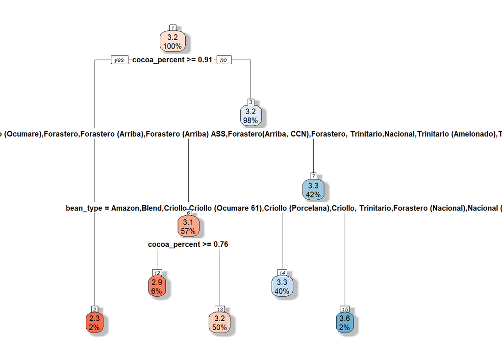

```r
# Visualization of the model
model$fit %>% rpart.plot(box.palette="RdBu", shadow.col="gray", nn=TRUE)
```

## Constructing the Second Model

I will construct the second model for a Decision Tree regression tree using the training dataset.

### Fit the Data

The following code will fit the data using the `chocolate_train` dataset which we partitioned from the original dataset. This will look at the variable `final_grade` in relation to `cocoa_percent`, `bean_type`, `broad_bean_origin`, and `review_date`.

```r
# Train the model
model2 <- model_spec %>%
  fit(formula = final_grade ~ cocoa_percent + bean_type + broad_bean_origin + review_date,
      data = chocolate_train)

# Information about the model
model2
```

```
## parsnip model object
##
## n= 1433
##
## node), split, n, deviance, yval
##       * denotes terminal node
##
##  1) root 1433 334.539700 3.183182
##    2) cocoa_percent>=0.905 22  10.536930 2.284091 *
##    3) cocoa_percent< 0.905 1411 305.941400 3.197201
##      6) broad_bean_origin= ,Africa, Carribean, C. Am.,Burma,Carribean,Central and S. America,Colombia, Ecuador,Cost Rica, Ven,Costa Rica,Ecuador, Mad., PNG,El Salvador,Ghana,Ghana & Madagascar,Ghana, Domin. Rep,Ghana, Panama, Ecuador,Grenada,India,Ivory Coast,Jamaica,Liberia,Martinique,Mexico,Per…
##       12) bean_type= ,Criollo,Criollo (Amarru),Criollo, Trinitario,Forastero,Forastero, Trinitario,Trinitario,Trinitario, Criollo,Trinitario, Forastero 359  92.007310 3.018106
##         24) broad_bean_origin= ,Africa, Carribean, C. Am.,Colombia, Ecuador,Cost Rica, Ven,Ghana, Domin. Rep,Ivory Coast,Martinique,Peru, Madagascar,Philippines,Principe,Puerto Rico,Sri Lanka,Trinidad-Tobago,Uganda,Venezuela, Trinidad,West Africa 76  23.289470 2.802632
##           48) review_date< 2007.5 12   5.807292 2.145833 *
##           49) review_date>=2007.5 64  11.334960 2.925781 *
##         25) broad_bean_origin=Burma,Carribean,Central and S. America,Costa Rica,El Salvador,Ghana,Grenada,India,Jamaica,Liberia,Mexico,Peru,Peru(SMartin,Pangoa,nacional),Peru, Ecuador, Venezuela,Sao Tome,South America, Africa,St. Lucia,Togo,Trinidad,Venezuela, Ghana 283  64.241610 3.075972 *
##       13) bean_type=Amazon mix,Blend,Forastero (Nacional),Matina 45  10.819440 3.361111 *
##      7) broad_bean_origin=Australia,Belize,Bolivia,Brazil,Cameroon,Colombia,Congo,Cuba,Dom. Rep., Madagascar,Domincan Republic,Dominican Rep., Bali,Dominican Republic,Ecuador,Fiji,Gabon,Gre., PNG, Haw., Haiti, Mad,Guat., D.R., Peru, Mad., PNG,Guatemala,Haiti,Hawaii,Honduras,Indonesia,Mad., Java, …
##       14) cocoa_percent>=0.745 264  51.625000 3.125000
##         28) broad_bean_origin=Bolivia,Colombia,Congo,Domincan Republic,Dominican Republic,Ecuador,Guatemala,Honduras,Madagascar,Nicaragua,Papua New Guinea,Tanzania,Vanuatu,Venezuela 198  39.865210 3.059343
##           56) review_date>=2006.5 188  35.089100 3.029255 *
##           57) review_date< 2006.5 10   1.406250 3.625000 *
##         29) broad_bean_origin=Belize,Brazil,Cuba,Fiji,Gabon,Guat., D.R., Peru, Mad., PNG,Haiti,Hawaii,Indonesia,Panama,Sao Tome & Principe,Solomon Islands,Trinidad, Ecuador,Ven.,Ecu.,Peru,Nic.,Venezuela/ Ghana,Vietnam 66   8.345644 3.321970 *
##       15) cocoa_percent< 0.745 743 129.619800 3.299462
##         30) bean_type= ,Amazon,Criollo,Criollo (Ocumare 61),Criollo (Porcelana),Forastero,Forastero (Arriba),Forastero (Arriba) ASS,Forastero (Nacional),Nacional,Nacional (Arriba),Trinitario,Trinitario (Amelonado),Trinitario, Criollo,Trinitario, Forastero 698 121.212800 3.280802 *
##         31) bean_type=Amazon, ICS,Beniano,Blend,Blend-Forastero,Criollo,CCN51,Criollo (Ocumare 77),Criollo (Wild),Criollo, +,Criollo, Trinitario,EET,Forastero (Amelonado),Forastero (Arriba) ASSS,Forastero (Catongo),Forastero (Parazinho),Trinitario (85% Criollo),Trinitario, TCGA 45   4.394444 3.58…
```

### Predict the Data

The following code will use the dataset `chocolate_test` to make predictions about `final_grade` using the model that was built.

```r
# Make predictions with the model.
predictions <- predict(model2,
                       new_data = chocolate_test) %>%
  bind_cols(chocolate_test)

predictions
```

| .pred | company | specific_bean_origin_or_bar_name | review_date | cocoa_percent | company_location | final_grade | bean_type | broad_bean_origin |
| --- | --- | --- | --- | --- | --- | --- | --- | --- |
| 3.075972 | A. Morin | Agua Grande | 2016 | 0.630 | France | 3.75 |  | Sao Tome |
| 3.075972 | A. Morin | Quilla | 2015 | 0.700 | France | 3.50 |  | Peru |
| 3.280802 | A. Morin | Carenero | 2014 | 0.700 | France | 2.75 | Criollo | Venezuela |
| 3.280802 | A. Morin | Puerto Cabello | 2014 | 0.700 | France | 3.75 | Criollo | Venezuela |
| 3.075972 | A. Morin | Pablino | 2014 | 0.700 | France | 4.00 |  | Peru |
| 3.280802 | A. Morin | Colombie | 2013 | 0.700 | France | 2.75 |  | Colombia |
| 3.280802 | A. Morin | Bolivia | 2012 | 0.700 | France | 3.50 |  | Bolivia |
| 3.280802 | Adi | Vanua Levu | 2011 | 0.600 | Fiji | 2.75 | Trinitario | Fiji |
| 3.321970 | Akesson's (Pralus) | Bali (west), Sukrama Family, Melaya area | 2011 | 0.750 | Switzerland | 3.75 | Trinitario | Indonesia |
| 3.321970 | Akesson's (Pralus) | Monte Alegre, D. Badero | 2010 | 0.750 | Switzerland | 2.75 | Forastero | Brazil |

[output cut: 350 more lines]

### Visualization

[figure not shown]

```r
# Visualization of the model
model2$fit %>% rpart.plot(box.palette="RdBu", shadow.col="gray", nn=TRUE)
```

# Random Forest

## Creating the Model

The following code create a random forest model.

```r
# creates the random forest model
(chocolate_rf <- ranger(final_grade ~ bean_type + cocoa_percent + broad_bean_origin,
                         chocolate_train,
                         num.trees=500,
                         respect.unordered.factors = "order",
                         seed=32022))
```

```
## Ranger result
##
## Call:
##  ranger(final_grade ~ bean_type + cocoa_percent + broad_bean_origin,      chocolate_train, num.trees = 500, respect.unordered.factors = "order",      seed = 32022)
##
## Type:                             Regression
## Number of trees:                  500
## Sample size:                      1433
## Number of independent variables:  3
## Mtry:                             1
## Target node size:                 5
## Variable importance mode:         none
## Splitrule:                        variance
## OOB prediction error (MSE):       0.2051888
## R squared (OOB):                  0.1216875
```

## Predictions and RMSE

The following code runs predictions using the random forest model and the RMSE (Root Mean Square Error).

```r
# Create a column called pred to store the prediction from the random forest model
chocolate_test$pred <- predict(chocolate_rf, chocolate_test)$predictions

# Calculate the RMSE of the predictions
chocolate_test %>%
  mutate(residual = final_grade - pred) %>%
  summarize(rmse = sqrt(mean(residual^2)))
```

| rmse |
| --- |
| 0.4268907 |

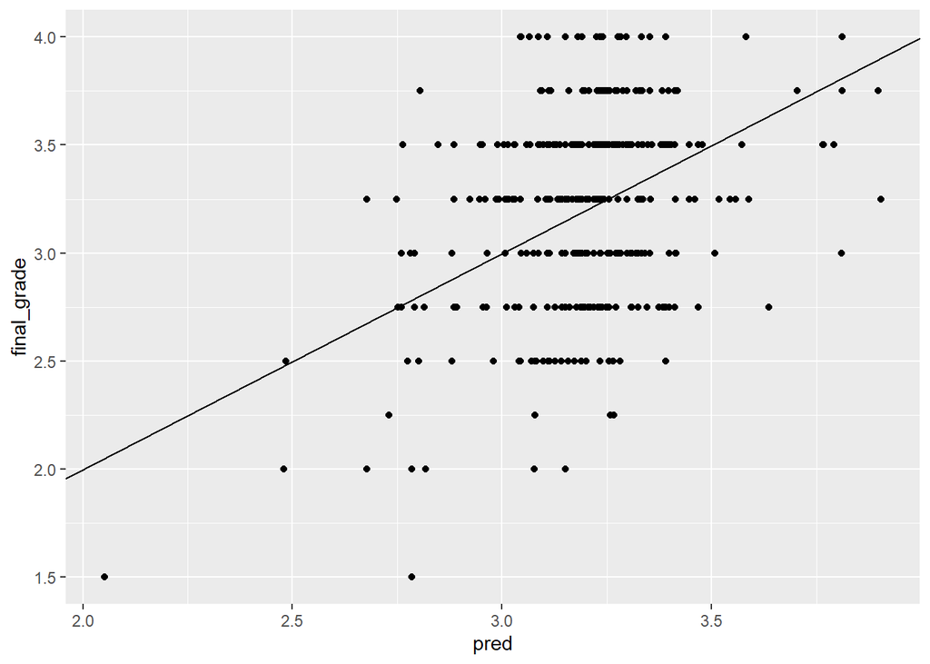

```r
# Plot the actual outcome vs predictions (prediction on the x-axis)
ggplot(chocolate_test, aes(x = pred, y = final_grade)) +
  geom_point() +
  geom_abline()
```

# Summary

The decision trees were quick to compute and provided preliminary information. However, care had to be taken in splitting the train and test data because the system would throw errors for new variables. I did find it more difficult to use the decision tree to do a continuous prediction as opposed to a regular classification.